# KDD2009naive

Win-Vector LLC

November 9, 2015

[KDD2009 naive example](http://www.sigkdd.org/kdd-cup-2009-customer-relationship-prediction). Winners had hold-out AUC of 0.7611 on churn. See [here](https://github.com/WinVector/zmPDSwR/tree/master/KDD2009) for more details.

This file is now not to do things (fixing problems as you find them). Instead use a systmetic variable tranformer such as vtreat.

```r
print(date())
```

```
## [1] "Mon Jul 18 13:23:20 2016"
```

```r
#load some libraries
# http://www.win-vector.com/blog/2014/08/vtreat-designing-a-package-for-variable-treatment/
library('vtreat')
# devtools::install_github("WinVector/WVPlots")
library('WVPlots')
library('parallel')
library('gbm')
library('ggplot2')
library('glmnet')
# load the data as in the book
# change this path to match your directory structure
dir = './'
debug = FALSE


d = read.table(paste(dir,'orange_small_train.data.gz',sep=''),
                header=T,sep='\t',na.strings=c('NA',''),
               stringsAsFactors=FALSE)
churn = read.table(paste(dir,'orange_small_train_churn.labels.txt',sep=''),
                    header=F,sep='\t')
d$churn = churn$V1
appetency = read.table(paste(dir,'orange_small_train_appetency.labels.txt',sep=''),
                        header=F,sep='\t')
d$appetency = appetency$V1
upselling = read.table(paste(dir,'orange_small_train_upselling.labels.txt',sep=''),
                        header=F,sep='\t')
d$upselling = upselling$V1
set.seed(729375)
rgroup = runif(dim(d)[[1]])
dTrainM = d[rgroup<=0.9,]  # set for building models
dTest = d[rgroup>0.9,] # set for evaluation
if(debug) {
  dTrainM <- dTrainM[sample.int(nrow(dTrainM),1000),]
  dTest <- dTest[sample.int(nrow(dTest),1000),]
}
rm(list=c('d','churn','appetency','upselling','dir'))
outcomes = c('churn','appetency','upselling')
nonvars <- c(outcomes,'rgroup')
vars = setdiff(colnames(dTrainM),
                nonvars)
yName = 'churn'
yTarget = 1
print(date())
```

```
## [1] "Mon Jul 18 13:23:27 2016"
```

```r
print(summary(dTrainM))
```

```
##       Var1             Var2            Var3               Var4
##  Min.   :  0.00   Min.   :0       Min.   :     0.0   Min.   : 0.00
##  1st Qu.:  0.00   1st Qu.:0       1st Qu.:     0.0   1st Qu.: 0.00
##  Median :  0.00   Median :0       Median :     0.0   Median : 0.00
##  Mean   : 11.85   Mean   :0       Mean   :   453.6   Mean   : 0.13
##  3rd Qu.: 16.00   3rd Qu.:0       3rd Qu.:     0.0   3rd Qu.: 0.00
##  Max.   :680.00   Max.   :5       Max.   :130668.0   Max.   :27.00
##  NA's   :44407    NA's   :43909   NA's   :43910      NA's   :43620
##       Var5              Var6             Var7           Var8
##  Min.   :      0   Min.   :     0   Min.   :  0.000   Mode:logical
##  1st Qu.:      0   1st Qu.:   518   1st Qu.:  0.000   NA's:45028
##  Median :      0   Median :   861   Median :  7.000
##  Mean   : 234375   Mean   :  1324   Mean   :  6.807
##  3rd Qu.: 116584   3rd Qu.:  1428   3rd Qu.:  7.000
##  Max.   :6048000   Max.   :114079   Max.   :140.000
##  NA's   :43682     NA's   :4959     NA's   :4971
##       Var9             Var10              Var11           Var12
##  Min.   :   0.00   Min.   :       0   Min.   : 8.00   Min.   :   0.00
##  1st Qu.:   4.00   1st Qu.:       0   1st Qu.: 8.00   1st Qu.:   0.00
##  Median :  20.00   Median :       0   Median : 8.00   Median :   0.00
##  Mean   :  48.98   Mean   :  394978   Mean   : 8.64   Mean   :  16.26
##  3rd Qu.:  44.00   3rd Qu.:  265230   3rd Qu.: 8.00   3rd Qu.:  16.00
##  Max.   :2300.00   Max.   :12325590   Max.   :40.00   Max.   :1184.00
##  NA's   :44407     NA's   :43682      NA's   :43910   NA's   :44533
##      Var13            Var14        Var15             Var16
##  Min.   :     0   Min.   : 0.00   Mode:logical   Min.   :  0.00
##  1st Qu.:     0   1st Qu.: 0.00   NA's:45028     1st Qu.: 51.92
##  Median :   232   Median : 0.00                  Median :129.68
##  Mean   :  1241   Mean   : 0.78                  Mean   :119.29
##  3rd Qu.:  1596   3rd Qu.: 0.00                  3rd Qu.:166.84
##  Max.   :197872   Max.   :48.00                  Max.   :375.32
##  NA's   :4971     NA's   :43910                  NA's   :43682
##      Var17            Var18            Var19        Var20
##  Min.   :  0.00   Min.   :  0.00   Min.   : 0.00   Mode:logical
##  1st Qu.:  0.00   1st Qu.:  0.00   1st Qu.: 0.00   NA's:45028
##  Median :  0.00   Median :  0.00   Median : 0.00
##  Mean   :  9.99   Mean   :  6.58   Mean   : 0.22
##  3rd Qu.: 10.00   3rd Qu.:  0.00   3rd Qu.: 0.00
##  Max.   :895.00   Max.   :948.00   Max.   :27.00
##  NA's   :43620    NA's   :43620    NA's   :43620
```

[output cut: 433 more lines]

```
##  Length:45028       Length:45028       Length:45028       Mode:logical
##  Class :character   Class :character   Class :character   NA's:45028
##  Mode  :character   Mode  :character   Mode  :character
##
##
##
##
##      churn           appetency         upselling
##  Min.   :-1.0000   Min.   :-1.0000   Min.   :-1.000
##  1st Qu.:-1.0000   1st Qu.:-1.0000   1st Qu.:-1.000
##  Median :-1.0000   Median :-1.0000   Median :-1.000
##  Mean   :-0.8526   Mean   :-0.9651   Mean   :-0.853
##  3rd Qu.:-1.0000   3rd Qu.:-1.0000   3rd Qu.:-1.000
##  Max.   : 1.0000   Max.   : 1.0000   Max.   : 1.000
##
```

The above data will not work with many machine learning algorithms (for example logistic regression, or random forests) due to implementations not liking at least one the many NA entries, and the presence of large categoricals. In addition many R implementations only accept a limited number of independent variable types. We will perform the minimum amount of “fixing” to make this dataset usable, however the transformations are complicated and in no sense optimal.

What we will do is:

- Change logical to numeric.
- Change numeric NA to 0.
- Temporarily change all factors to character types (to make sure there are no unused levels).
- Change all character NA and levels not seen during training to “” (blank).
- Then change all character types to factor (as this is what gbm accepts, though we are using glm).
- Limit down only input variables that have more than one value and categoricals that have no more than 200 values.

This “minimal” set of transformations is a bit involved, is not very faithful to the original data, and still may miss corner cases. This is why this step is worth automating.

```r
print(date())
```

```
## [1] "Mon Jul 18 13:23:28 2016"
```

```r
# naively transform data
cleanColumn <- function(c,targetSet) {
  if(is.logical(c)) {
    c <- as.numeric(c)
  }
  if(is.numeric(c)) {
    c[is.na(c)] <- 0
  }
  if(is.factor(c)) {
    c <- as.character(c)
  }
  if(is.character(c)) {
    c[is.na(c)] <- ''
    if(!is.null(targetSet)) {
      c[!(c %in% targetSet)] <- ''
    }
  }
  c
}
treatedTrainM <- dTrainM
treatedTest <- dTest
for(cn in vars) {
  treatedTrainM[[cn]] <- cleanColumn(dTrainM[[cn]],NULL)
  treatedTest[[cn]] <- cleanColumn(dTest[[cn]],unique(treatedTrainM[[cn]]))
  if(is.character(treatedTrainM[[cn]])) {
     levs <- sort(unique(c('',treatedTrainM[[cn]])))
     treatedTrainM[[cn]] <- factor(treatedTrainM[[cn]],levs)
     treatedTest[[cn]] <- factor(treatedTest[[cn]],levs)
  }
}
treatedTrainM[[yName]] = treatedTrainM[[yName]]==yTarget
treatedTest[[yName]] = treatedTest[[yName]]==yTarget
canUse <- vapply(vars,
                 function(cn) { (length(unique(treatedTrainM[[cn]]))>1) &&
                     ( (!is.factor(treatedTrainM[[cn]])) ||
                         (length(unique(treatedTrainM[[cn]]))<=200) ) },
                 logical(1))
selvars <- vars[canUse]
print(date())
```

```
## [1] "Mon Jul 18 13:23:29 2016"
```

```r
print(date())
```

```
## [1] "Mon Jul 18 13:23:29 2016"
```

```r
print(selvars)
```

```
##   [1] "Var1"   "Var2"   "Var3"   "Var4"   "Var5"   "Var6"   "Var7"
##   [8] "Var9"   "Var10"  "Var11"  "Var12"  "Var13"  "Var14"  "Var16"
##  [15] "Var17"  "Var18"  "Var19"  "Var21"  "Var22"  "Var23"  "Var24"
##  [22] "Var25"  "Var26"  "Var27"  "Var28"  "Var29"  "Var30"  "Var33"
##  [29] "Var34"  "Var35"  "Var36"  "Var37"  "Var38"  "Var40"  "Var41"
##  [36] "Var43"  "Var44"  "Var45"  "Var46"  "Var47"  "Var49"  "Var50"
##  [43] "Var51"  "Var53"  "Var54"  "Var56"  "Var57"  "Var58"  "Var59"
##  [50] "Var60"  "Var61"  "Var62"  "Var63"  "Var64"  "Var65"  "Var66"
##  [57] "Var67"  "Var68"  "Var69"  "Var70"  "Var71"  "Var72"  "Var73"
##  [64] "Var74"  "Var75"  "Var76"  "Var77"  "Var78"  "Var80"  "Var81"
##  [71] "Var82"  "Var83"  "Var84"  "Var85"  "Var86"  "Var87"  "Var88"
##  [78] "Var89"  "Var90"  "Var91"  "Var92"  "Var93"  "Var94"  "Var95"
##  [85] "Var96"  "Var97"  "Var98"  "Var99"  "Var100" "Var101" "Var102"
##  [92] "Var103" "Var104" "Var105" "Var106" "Var107" "Var108" "Var109"
##  [99] "Var110" "Var111" "Var112" "Var113" "Var114" "Var115" "Var116"
## [106] "Var117" "Var118" "Var119" "Var120" "Var121" "Var122" "Var123"
## [113] "Var124" "Var125" "Var126" "Var127" "Var128" "Var129" "Var130"
## [120] "Var131" "Var132" "Var133" "Var134" "Var135" "Var136" "Var137"
## [127] "Var138" "Var139" "Var140" "Var142" "Var143" "Var144" "Var145"
## [134] "Var146" "Var147" "Var148" "Var149" "Var150" "Var151" "Var152"
## [141] "Var153" "Var154" "Var155" "Var156" "Var157" "Var158" "Var159"
## [148] "Var160" "Var161" "Var162" "Var163" "Var164" "Var165" "Var166"
## [155] "Var168" "Var170" "Var171" "Var172" "Var173" "Var174" "Var176"
## [162] "Var177" "Var178" "Var179" "Var180" "Var181" "Var182" "Var183"
## [169] "Var184" "Var186" "Var187" "Var188" "Var189" "Var190" "Var191"
## [176] "Var193" "Var194" "Var195" "Var196" "Var201" "Var203" "Var204"
## [183] "Var205" "Var206" "Var207" "Var208" "Var210" "Var211" "Var212"
## [190] "Var213" "Var215" "Var218" "Var219" "Var221" "Var223" "Var224"
## [197] "Var225" "Var226" "Var227" "Var228" "Var229"
```

```r
# look for novel levels in test
hasNoNovelLevels <- logical(nrow(treatedTest))
hasNoNovelLevels <- TRUE
for(v in vars) {
  if(is.factor(treatedTrainM[[v]])) {
     hasNoNovelLevels <- hasNoNovelLevels & (treatedTest[[v]] %in% unique(treatedTrainM[[v]]))
  }
}
print(summary(hasNoNovelLevels))
```

```
##    Mode   FALSE    TRUE    NA's
## logical     373    4599       0
```

```r
# prepare plotting frames
treatedTrainP = treatedTrainM[, yName, drop=FALSE]
treatedTestP = treatedTest[, yName, drop=FALSE]

formulaS = paste(yName,paste(selvars,collapse=' + '),sep=' ~ ')
```

Try gbm modeling.

```r
# errors out, presumably during its own cross val!
modelGBMs = gbm(as.formula(formulaS),
                data=treatedTrainM,
                distribution='bernoulli',
                n.trees=1000,
                interaction.depth=3,
                keep.data=FALSE,
                cv.folds=5)
```

```
## Error in object$var.levels[[i]]: subscript out of bounds
```

```r
# try again without cross val, giving up features to get a run.
mname = 'gbmPred'
modelGBMs = gbm(as.formula(formulaS),
                data=treatedTrainM,
                distribution='bernoulli',
                n.trees=1000,
                interaction.depth=3,
                keep.data=FALSE)
#print(modelGBMs)
#print(summary(modelGBMs))
nTrees = gbm.perf(modelGBMs)
```

```
## Using OOB method...
```

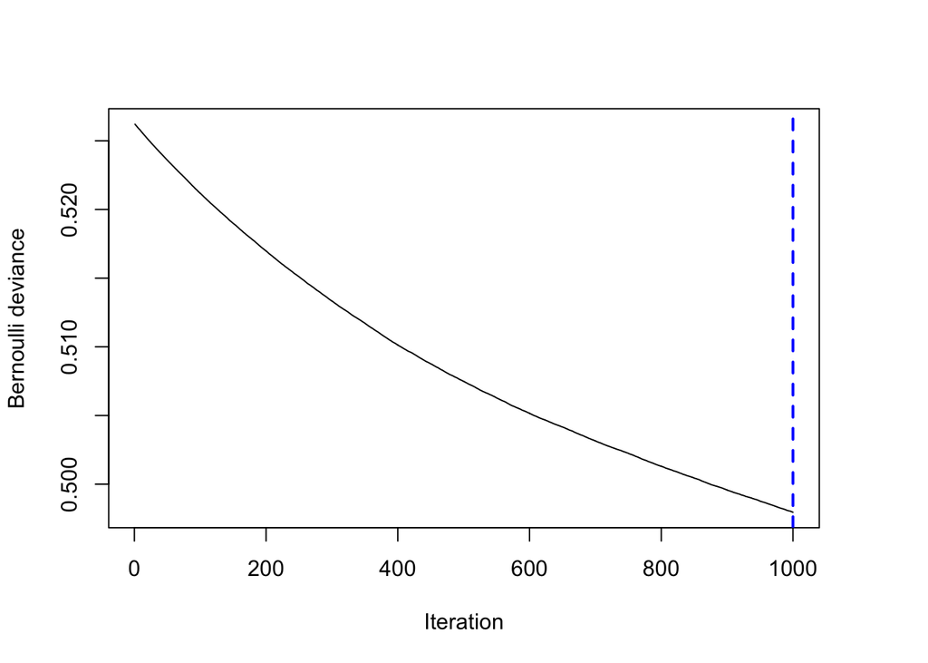

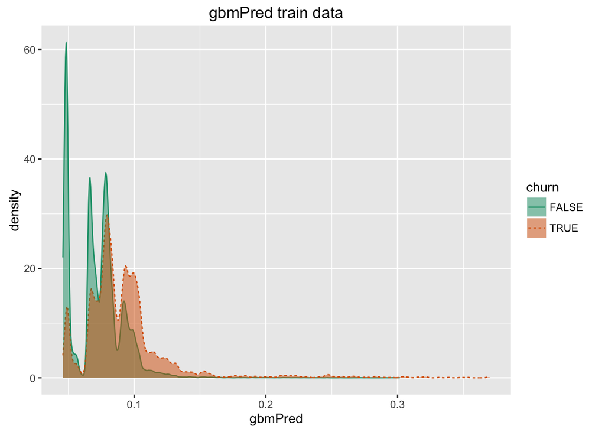

```r
treatedTrainP[[mname]] = predict(modelGBMs,
                                 newdata=treatedTrainM,type='response',
                                 n.trees=nTrees)


t1 = paste(mname,'train data')
print(DoubleDensityPlot(treatedTrainP, mname, yName,
                        title=t1))
```

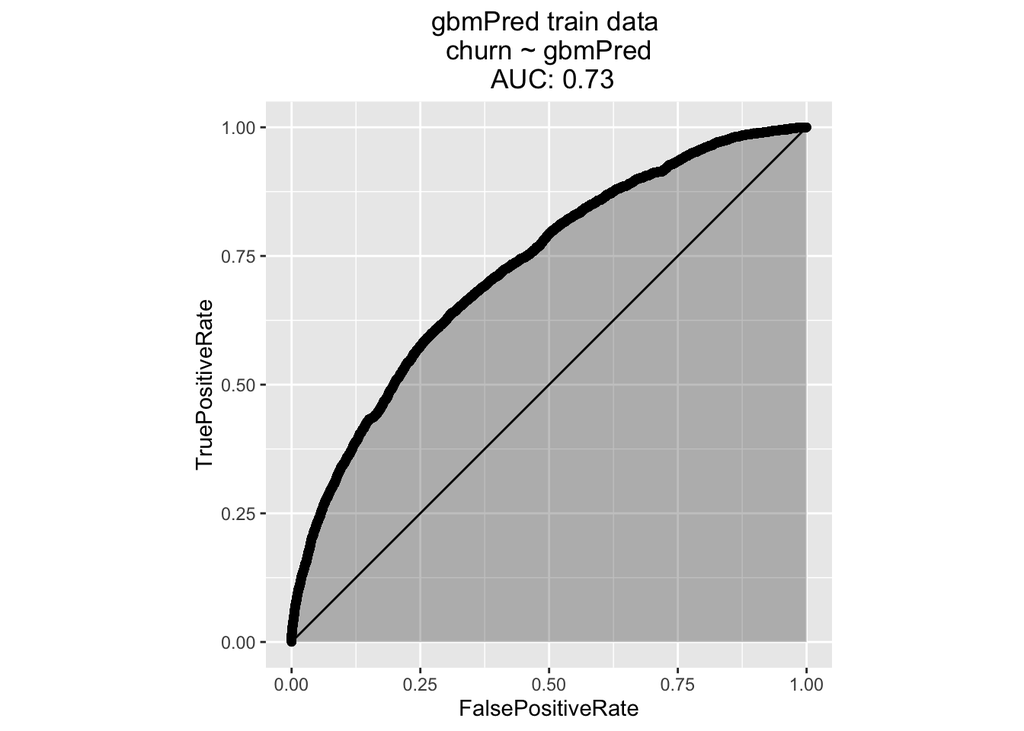

```r
print(ROCPlot(treatedTrainP, mname, yName,
              title=t1))
```

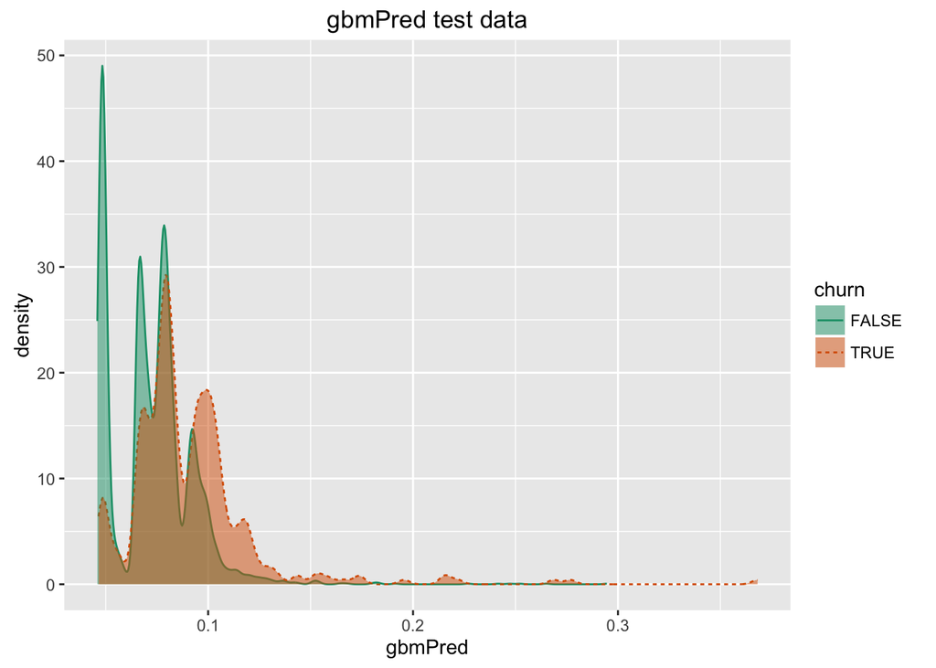

```r
t2 = paste(mname,'test data')
treatedTestP[[mname]] = predict(modelGBMs,
                                    newdata=treatedTest,type='response',
                                    n.trees=nTrees)
print(DoubleDensityPlot(treatedTestP, mname, yName,
                        title=t2))
```

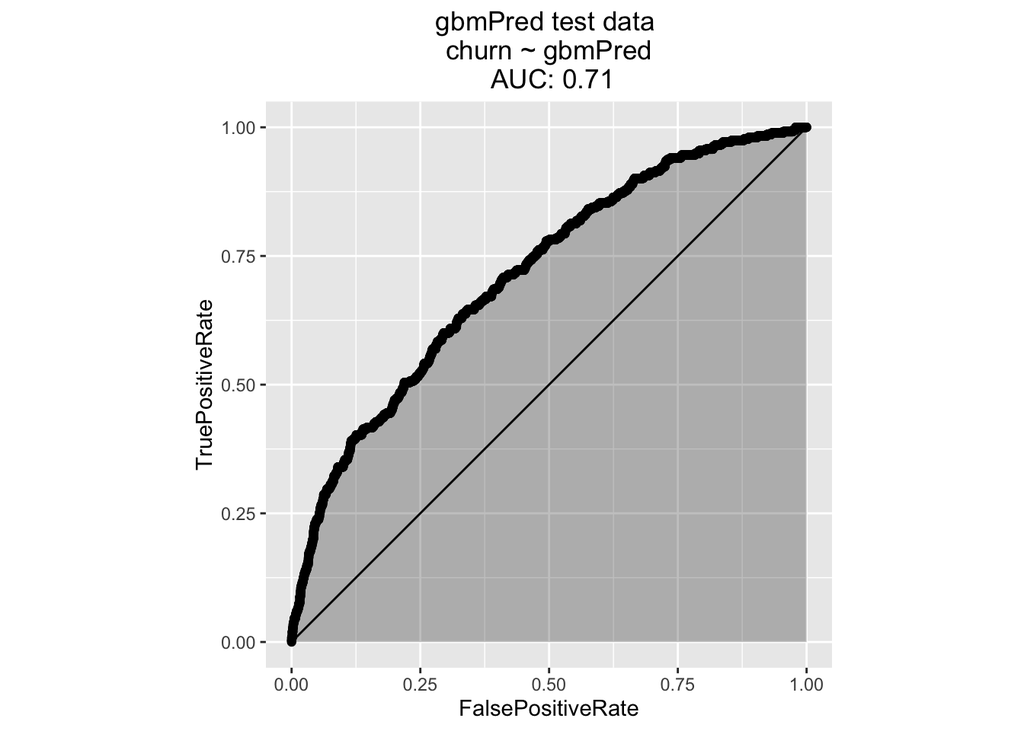

```r
print(ROCPlot(treatedTestP, mname, yName,
              title=t2))
```

```r
print(date())
```

```
## [1] "Mon Jul 18 13:42:48 2016"
```

Try elastic net glm modeling. No formula intervace, so we have to call model matrix ourselves. We go to the trouble of binding the data together to gaurantee a joint encoding (deals with both issues of novel levels and missing levels which arise when the set of levels seen in training and test are not the same).

```r
nTrain <- nrow(treatedTrainM)
jointData <- rbind(treatedTrainM[,selvars,drop=FALSE],treatedTest[,selvars,drop=FALSE])
jointData <- model.matrix(as.formula(paste('',paste(selvars,collapse=' + '),sep=' ~ ')),
                                        jointData)
# get rid of intercept
jointData <- jointData[,-1]
mvars <- colnames(jointData)
# put back in frames
treatedTrainJ <- jointData[seq_len(nTrain),]
treatedTestJ <- jointData[-seq_len(nTrain),]
```

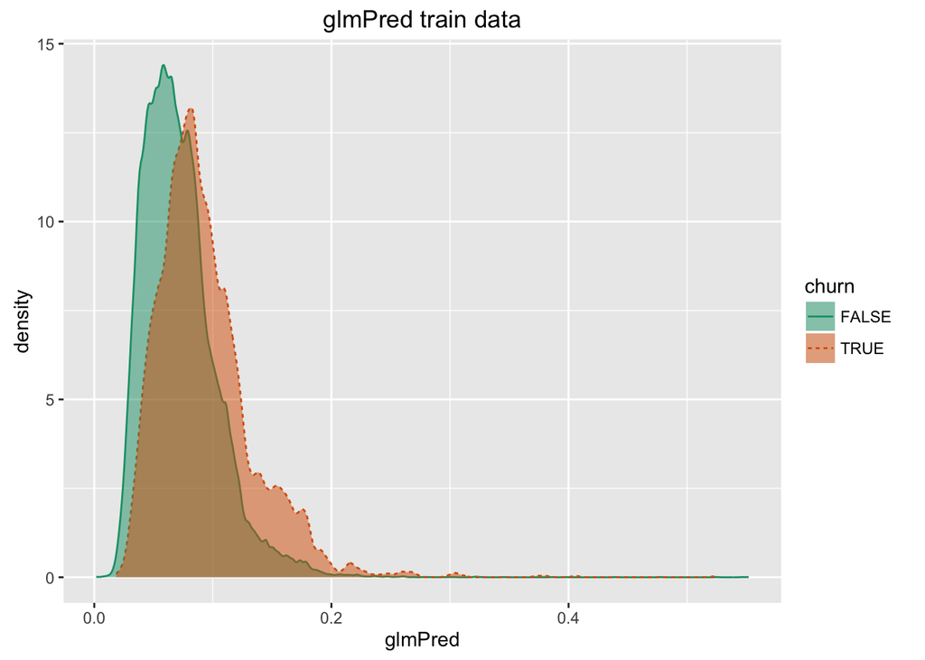

```r
mname = 'glmPred'
modelglms = cv.glmnet(x = treatedTrainJ,
                      y = treatedTrainM[[yName]],
                      alpha=0.5,
                      family='binomial')
#print(summary(modelglms))
treatedTrainP[[mname]] = as.numeric(predict(modelglms,
                                            newx=treatedTrainJ,
                                            type='response'))
treatedTestP[[mname]] = as.numeric(predict(modelglms,
                                           newx=treatedTestJ,
                                           type='response'))
t1 = paste(mname,'train data')
print(DoubleDensityPlot(treatedTrainP, mname, yName,
                        title=t1))
```

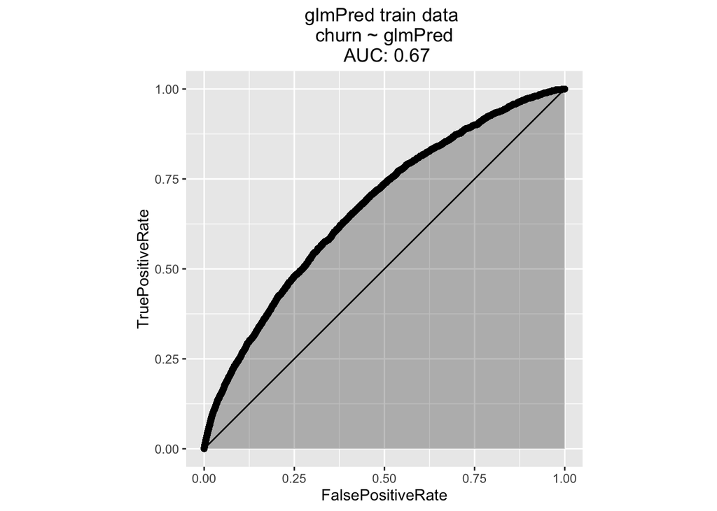

```r
print(ROCPlot(treatedTrainP, mname, yName,
              title=t1))
```

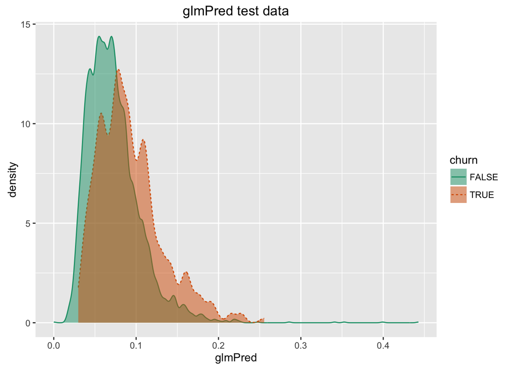

```r
t2 = paste(mname,'test data')
print(DoubleDensityPlot(treatedTestP, mname, yName,
                        title=t2))
```

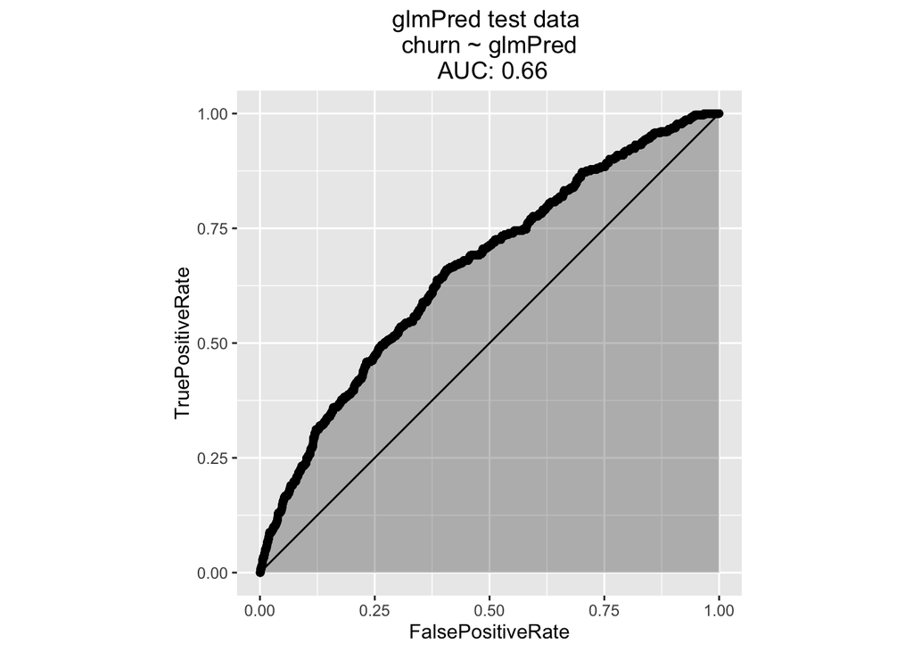

```r
print(ROCPlot(treatedTestP, mname, yName,
              title=t2))
```

Practical Data Science with R’s demonstration avoided this over-fit by pruning variables in a y-away way on a set disjoint from the preperation set.

We have documented and automated a consistent workflow using *vtreat::mkCrossFrameCExperiment* that extracts as much fitting power as practical.